# Introduction to R

## Overview

This is a series of R, statistics and conservation workshops.

The goals of these workshops are to:

- Introduce R
- Introduce basic concepts of statistics
- Apply the conceps from R and statistics to conservation problems

## What is R and RStudio?

R is a open-source programming language commonly used for statistics

RStudio is an integrated development environment (IDE) for R – A nice place to use R

## Why use R?

- R is free!
- R is the most common software used for statistical analyses
- R has an amazing community

## What can I do with R?

- From simple graphs
- Interactive web apps
- Documents/ notebooks
- Spatial analysis
- Statistical analysis
- Much more!

## R packages

R allows you to use packages (functions developed by others). By including these packages, you can expand the capabilities of R.

In ecology the following packages are very useful:

- Community ecology ([vegan](https://cran.r-project.org/web/packages/vegan/vignettes/intro-vegan.pdf))
- Spatial analysis ([raster](https://cran.r-project.org/web/packages/raster/raster.pdf), [sf](https://cran.r-project.org/web/packages/sf/sf.pdf), [sp](https://cran.r-project.org/web/packages/sp/sp.pdf), [rgdal](https://cran.r-project.org/web/packages/rgdal/rgdal.pdf), [rgeos](https://cran.rstudio.com/web/packages/rgeos/rgeos.pdf))
- Phylogenetic analysis ([geiger](https://cran.r-project.org/web/packages/geiger/geiger.pdf), [ape](https://cran.r-project.org/web/packages/ape/ape.pdf), [phytools](https://cran.r-project.org/web/packages/phytools/phytools.pdf))
- Network analysis ([igraph](https://igraph.org/r/), [network](https://cran.r-project.org/web/packages/network/vignettes/networkVignette.pdf))
- Landscape ecology ([landscapemetrics](https://r-spatialecology.github.io/landscapemetrics/))

## R packages

Packages from [tidyverse](https://www.tidyverse.org) are particularly useful for data cleaning and wrangling.

[figure not shown]

## You can use R to produce really cool graphs!

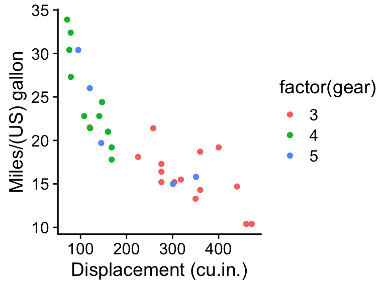

```r
ggplot(data = mtcars, aes(x = disp, y = mpg, colour = factor(gear))) +
    geom_point() + theme_cowplot() + xlab("Displacement (cu.in.)") +
    ylab("Miles/(US) gallon")
```

## Shiny apps

[covid tracker](https://shiny.rstudio.com/gallery/covid19-tracker.html)

[figure not shown]

## RMarkdown

- [Books!](https://bookdown.org/yihui/bookdown/)
- [Presentations](http://svmiller.com/rmarkdown-example.pdf)! (like this one)
- [Documents](http://timelyportfolio.github.io/rCharts_nyt_home_price/)
- [Websites](https://rmarkdown.rstudio.com)

## Simulations

Mathematics are integral to ecology. You may have learned about Lotka-Volterra equations. These equations describe the dynamics of a predator and a prey.

\[ \frac{dx}{dt} = Ax - Bxy \\ \frac{dy}{dt} = Cxy - Dy \]

## Simulations

We can solve these differential equations in R!

```r
library(deSolve)
parameters<-c(A=1,B=0.2,C=0.08,D=0.5)
state<-c(x=5,y=2)

LV<-function(t,state,parameters){ with(as.list(c(state,parameters)),{
  dxOVERdt<-(A*x-B*x*y)
  dyOVERdt<-(C*y*x-D*y)
  return(list(c(dxOVERdt,dyOVERdt)))
}) }
times<-seq(0, 100,by = 0.01)
out<-ode(y=state, times=times, func=LV, parms=parameters)
```

## Simulations

And plot the dynamics of these populations.

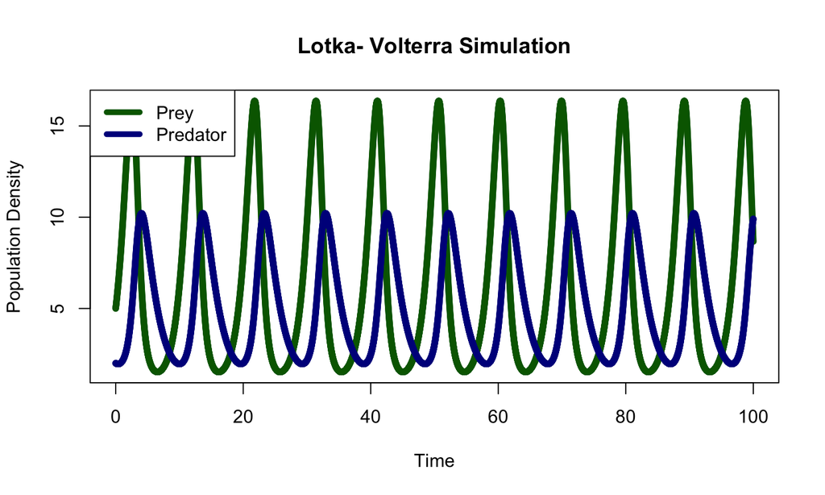

## Functions

R has many built in functions or you can load many more using packages.

You can also write your own. They are specially useful if you need to repeat the same code multiple times.

```r
my_function <- function(a, b){
  a*b
}
```

## Statistics

## Spatial analysis

For more info see this [book](https://cengel.github.io/R-spatial/)!

## Interaction between R and other softwares

- [Rcpp](http://adv-r.had.co.nz/Rcpp.html)
- [Excel](https://readxl.tidyverse.org)
- GIS
- Web scrapping/ API